# Tugas Praktikum 4_ARMA

## Scatter Plot Antar Lag

### Korelasi antara Yt dengan Yt−1

```r
length(arma22)
```

```
## [1] 300
```

```r
# Y_t
yt_arma <- arma22[3:300]
yt_arma
```

```
##   [1] -2.98064692 -1.12111691 -1.75293106 -1.33898765 -2.09046996 -3.56829323
##   [7] -4.32225209 -6.49932813 -7.02769509 -6.95242810 -6.26996407 -3.43890672
##  [13] -3.74182891 -2.97181976 -3.49823015 -3.96328709 -4.21591372 -4.99194225
##  [19] -5.61517562 -5.49498965 -5.32810268 -6.08211738 -5.70927763 -6.49640104
##  [25] -6.19781946 -5.63181804 -4.16631811 -1.43386858 -1.32659085  1.33518960
##  [31] -0.57718012  1.13545868  2.56923465  2.89049818  2.80495292  1.68426168
##  [37]  2.77538382  1.29220743  3.17981524  3.04188012  3.84589813  3.47054592
##  [43]  2.25362466  1.27634579  1.31729358  3.02358708  2.83893413  1.81428668
##  [49]  0.10302896 -0.45121970 -0.85290753 -0.66635425 -0.93510416 -2.14779642
##  [55] -2.08562341 -1.51503473 -0.24121274  0.91556687  0.64537308  0.48311177
##  [61] -1.14217407 -1.12039092 -1.27141453  0.91636167  2.04091439  2.13232979
##  [67]  2.23257264  0.25301429  1.21071226  1.29939237  3.92904462  4.07112121
##  [73]  3.78513073  2.83160983  1.41191959  0.28488816 -0.04006883 -1.28812485
##  [79] -0.74220308 -0.74424287 -0.32976863 -0.31752860 -0.98342470 -2.04217397
##  [85] -1.20184647 -1.31314616  0.45270778 -0.93468943 -0.20680752 -0.29613748
```

[output cut: 35 more lines]

```r
# Y_{t-1}
yt_1_arma <- arma22[2:299]
yt_1_arma
```

```
##   [1] -1.74814288 -2.98064692 -1.12111691 -1.75293106 -1.33898765 -2.09046996
##   [7] -3.56829323 -4.32225209 -6.49932813 -7.02769509 -6.95242810 -6.26996407
##  [13] -3.43890672 -3.74182891 -2.97181976 -3.49823015 -3.96328709 -4.21591372
##  [19] -4.99194225 -5.61517562 -5.49498965 -5.32810268 -6.08211738 -5.70927763
##  [25] -6.49640104 -6.19781946 -5.63181804 -4.16631811 -1.43386858 -1.32659085
##  [31]  1.33518960 -0.57718012  1.13545868  2.56923465  2.89049818  2.80495292
##  [37]  1.68426168  2.77538382  1.29220743  3.17981524  3.04188012  3.84589813
##  [43]  3.47054592  2.25362466  1.27634579  1.31729358  3.02358708  2.83893413
##  [49]  1.81428668  0.10302896 -0.45121970 -0.85290753 -0.66635425 -0.93510416
##  [55] -2.14779642 -2.08562341 -1.51503473 -0.24121274  0.91556687  0.64537308
##  [61]  0.48311177 -1.14217407 -1.12039092 -1.27141453  0.91636167  2.04091439
##  [67]  2.13232979  2.23257264  0.25301429  1.21071226  1.29939237  3.92904462
##  [73]  4.07112121  3.78513073  2.83160983  1.41191959  0.28488816 -0.04006883
##  [79] -1.28812485 -0.74220308 -0.74424287 -0.32976863 -0.31752860 -0.98342470
##  [85] -2.04217397 -1.20184647 -1.31314616  0.45270778 -0.93468943 -0.20680752
```

[output cut: 35 more lines]

[figure not shown]

```r
# Scatterplot Y_t vs Y_{t-1}
par(mfrow=c(2,2))

plot(yt_1_arma, yt_arma,
     main="Y_t vs Y_{t-1}",
     xlab="Y_{t-1}", ylab="Y_t",
     pch=19, col="blue")
```

Berdasarkan scatterplot tersebut, terlihat bahwa terdapat hubungan positif antara Yt dengan Yt−1. Hal ini sesuai dengan teori yang ada

```r
cor(yt_arma,yt_1_arma)
```

```
## [1] 0.8917064
```

**Perhitungan manual:**

Model ARMA(2,2):

$$Y_t = 0.5\, Y_{t-1} + 0.2\, Y_{t-2} + \varepsilon_t + 0.4\,
\varepsilon_{t-1} + 0.6\, \varepsilon_{t-2}, \quad
\text{Var}(\varepsilon_t)=1$$

Rumus varians:

$$\gamma_0 = \frac{1 + \theta_1^2 + \theta_2^2 + 2 \theta_1 \theta_2}{1 -
\phi_1^2 - \phi_2^2 - 2 \phi_1 \phi_2}
= \frac{1 + 0.4^2 + 0.6^2 + 2 \cdot 0.4 \cdot 0.6}{1 - 0.5^2 - 0.2^2 - 2
\cdot 0.5 \cdot 0.2} \approx 3.92$$

Rumus kovarians lag 1:

$$\gamma_1 \approx \phi_1 + \theta_1 + \phi_2 \theta_1 + \phi_1 \theta_2 =
0.5 + 0.4 + 0.2 \cdot 0.4 + 0.5 \cdot 0.6 = 1.28$$

Berdasarkan simulasi R hasil simulasi 300 data: **ρ₁ ≈ 0.892**

### Korelasi antara Yt dengan Yt−2

```r
yt_2_arma <- arma22[1:298]
yt_2_arma
```

```
##   [1] -2.75189059 -1.74814288 -2.98064692 -1.12111691 -1.75293106 -1.33898765
##   [7] -2.09046996 -3.56829323 -4.32225209 -6.49932813 -7.02769509 -6.95242810
##  [13] -6.26996407 -3.43890672 -3.74182891 -2.97181976 -3.49823015 -3.96328709
##  [19] -4.21591372 -4.99194225 -5.61517562 -5.49498965 -5.32810268 -6.08211738
##  [25] -5.70927763 -6.49640104 -6.19781946 -5.63181804 -4.16631811 -1.43386858
##  [31] -1.32659085  1.33518960 -0.57718012  1.13545868  2.56923465  2.89049818
##  [37]  2.80495292  1.68426168  2.77538382  1.29220743  3.17981524  3.04188012
##  [43]  3.84589813  3.47054592  2.25362466  1.27634579  1.31729358  3.02358708
##  [49]  2.83893413  1.81428668  0.10302896 -0.45121970 -0.85290753 -0.66635425
##  [55] -0.93510416 -2.14779642 -2.08562341 -1.51503473 -0.24121274  0.91556687
##  [61]  0.64537308  0.48311177 -1.14217407 -1.12039092 -1.27141453  0.91636167
##  [67]  2.04091439  2.13232979  2.23257264  0.25301429  1.21071226  1.29939237
##  [73]  3.92904462  4.07112121  3.78513073  2.83160983  1.41191959  0.28488816
##  [79] -0.04006883 -1.28812485 -0.74220308 -0.74424287 -0.32976863 -0.31752860
##  [85] -0.98342470 -2.04217397 -1.20184647 -1.31314616  0.45270778 -0.93468943
```

[output cut: 35 more lines]

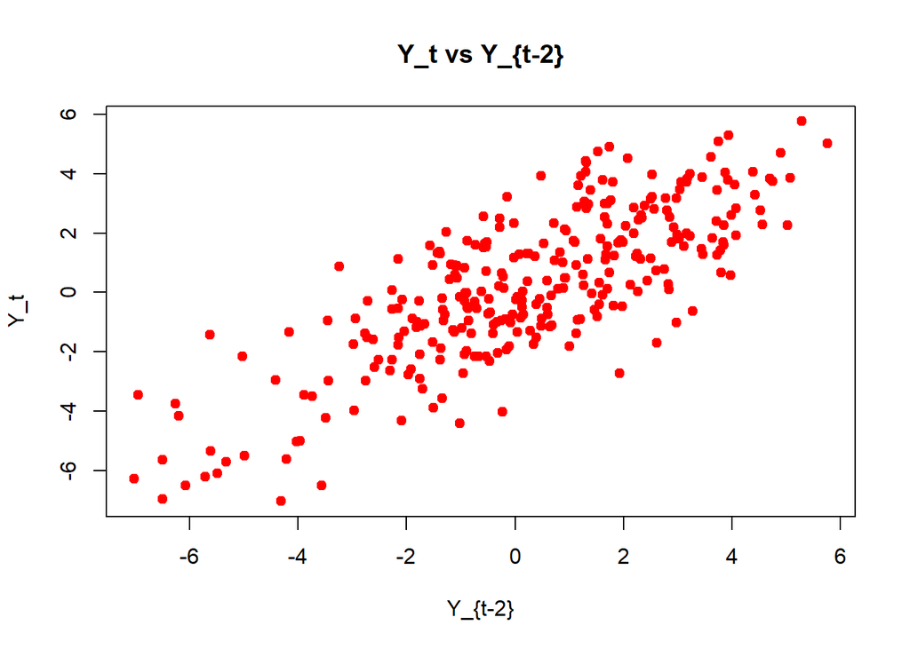

```r
plot(yt_2_arma, yt_arma,
     main="Y_t vs Y_{t-2}",
     xlab="Y_{t-2}", ylab="Y_t",
     pch=19, col="red")
```

Berdasarkan scatterplot tersebut, terlihat bahwa terdapat hubungan positif antara Yt dengan Yt−2. Hal ini sesuai dengan teori yang ada

```r
cor(yt_arma,yt_2_arma)
```

```
## [1] 0.7836583
```

**Perhitungan manual:**

$$\rho_2 \approx \frac{\phi_2 + \phi_1 \rho_1 + \theta_2 + \theta_1
\rho_1}{1 + \theta_1^2 + \theta_2^2 + 2 \theta_1 \theta_2}
\approx \frac{0.2 + 0.5\cdot0.64 + 0.6 + 0.4\cdot0.64}{2} \approx 0.688$$

Hasil simulasi R: ρ₂ ≈ 0.784

Nilai sample autocorrelation lebih tinggi karena acak noise dan jumlah data terbatas; nilai sample akan mendekati teoritis jika data diperbanyak.

```r
yt_3_arma <- arma22[0:297+3]
yt_3_arma
```

```
##   [1] -2.98064692 -1.12111691 -1.75293106 -1.33898765 -2.09046996 -3.56829323
##   [7] -4.32225209 -6.49932813 -7.02769509 -6.95242810 -6.26996407 -3.43890672
##  [13] -3.74182891 -2.97181976 -3.49823015 -3.96328709 -4.21591372 -4.99194225
##  [19] -5.61517562 -5.49498965 -5.32810268 -6.08211738 -5.70927763 -6.49640104
##  [25] -6.19781946 -5.63181804 -4.16631811 -1.43386858 -1.32659085  1.33518960
##  [31] -0.57718012  1.13545868  2.56923465  2.89049818  2.80495292  1.68426168
##  [37]  2.77538382  1.29220743  3.17981524  3.04188012  3.84589813  3.47054592
##  [43]  2.25362466  1.27634579  1.31729358  3.02358708  2.83893413  1.81428668
##  [49]  0.10302896 -0.45121970 -0.85290753 -0.66635425 -0.93510416 -2.14779642
##  [55] -2.08562341 -1.51503473 -0.24121274  0.91556687  0.64537308  0.48311177
##  [61] -1.14217407 -1.12039092 -1.27141453  0.91636167  2.04091439  2.13232979
##  [67]  2.23257264  0.25301429  1.21071226  1.29939237  3.92904462  4.07112121
##  [73]  3.78513073  2.83160983  1.41191959  0.28488816 -0.04006883 -1.28812485
##  [79] -0.74220308 -0.74424287 -0.32976863 -0.31752860 -0.98342470 -2.04217397
##  [85] -1.20184647 -1.31314616  0.45270778 -0.93468943 -0.20680752 -0.29613748
```

[output cut: 35 more lines]

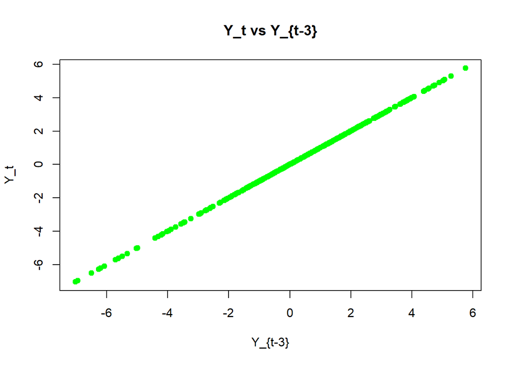

```r
plot(yt_3_arma, yt_arma,
     main="Y_t vs Y_{t-3}",
     xlab="Y_{t-3}", ylab="Y_t",
     pch=19, col="green")
```

```r
cor(yt_arma,yt_3_arma)
```

```
## [1] 1
```

**Perhitungan manual (pendekatan sederhana):**

$$\rho_3 \approx \phi_1 \rho_2 + \phi_2 \rho_1 = 0.5 \cdot 0.688 + 0.2
\cdot 0.64 \approx 0.504$$

**Hasil simulasi R:**